# Example Analysis of Data from the IEU GWAS Database

Here, we will demonstrate how to use bivariate data sources (in particular, the MR-Base database) to bound the average treatment effect, and gain insights into what such bounds would look like if a trivariate data set was available.

# Effect of Smoking on Lung Cancer

Our first example will use smoking as exposure, and lung cancer as outcome (both as binary).

```r
library(TwoSampleMR)
library(tidyverse)
library(magrittr)
library(ACEBounds)


theme_set(theme_bw())
```

## Collect Data

Using the `TwoSampleMR` package, we get the data from the online database. First, we get a `tibble` with all available outcomes.

```r
ao <- available_outcomes()
```

From this, we identify an experiment. We save information about the experiment to the `smoking_experiment` object.

```r
smoking_experiment <- ao %>% filter(id == "ukb-d-20116_0")
```

Next, we obtain potential instruments for the exposure variable.

```r
smoking_instruments <- extract_instruments(smoking_experiment$id)
```

Similarly, we obtain outcome data: identify an appropriate study with data on lung cancer, and create an object with the information available about that study. We call this object `lung_cancer_experiment`.

```r
lung_cancer_experiment <- ao %>% filter(id == "ukb-d-40001_C349")
lung_cancer_data <- extract_outcome_data(snps = smoking_instruments$SNP, outcomes = lung_cancer_experiment$id)
```

```
## Extracting data for 84 SNP(s) from 1 GWAS(s)
```

Finally, we extract data from the study.

```r
smoking_lung_cancer_harmonized <- harmonise_data(smoking_instruments, lung_cancer_data) %>% as_tibble()
```

```
## Harmonising Smoking status: Never || id:ukb-d-20116_0 (ukb-d-20116_0) and Underlying (primary) cause of death: ICD10: C34.9 Bronchus or lung, unspecified || id:ukb-d-40001_C349 (ukb-d-40001_C349)
```

```
## Removing the following SNPs for being palindromic with intermediate allele frequencies:
## rs11693702, rs1492546, rs2240294, rs264974, rs568599
```

```r
smoking_lung_cancer_pop_probs <- tibble(regression = c("outcome", "exposure"),
                                       p_outcome = c(lung_cancer_experiment  %$% { ncase / (ncase + ncontrol) },
                                                     smoking_experiment %$% { ncase / (ncase + ncontrol) }))
```

The following helper function takes finds the intercept in logistic regression that ensures the marginal probabilities $P(Y = 1)$ and $P(X = 1)$ match what’s observed given the marginal distributions of the dependendt (i.e. either smoking or lung cancer) and the IV (SNPs).

```r
find_intercept <- function(beta1, p_outcome, pz, interval = c(-5, 5), zs = 0:2){
  uniroot(f = function(beta0) sum((1+exp(-beta0-beta1*zs))^(-1) * pz) - p_outcome,
          interval = interval)
}
```

We have $P(X = 1)$ and $P(Y = 1)$. We still need $P(Z = z)$. These can be found from the allele frequencies. Since we have data on $Z$ from two separate sources, and the allele frequencies vary ever so slightly between the two, we use a weighted average of the allele frequencies as our final estimates. With these estimated allele frequencies, we can find $P(Z = z)$.

```r
smoking_lung_cancer_prep_for_bounds <- smoking_lung_cancer_harmonized %>%
  rowwise() %>%
  mutate(samplesize.exposure = smoking_experiment$ncase + smoking_experiment$ncontrol,
         samplesize.outcome = lung_cancer_experiment$ncase + lung_cancer_experiment$ncontrol,
         ave_eaf = weighted.mean(x = c_across(c(eaf.exposure, eaf.outcome)),
                                 w = c_across(c(samplesize.exposure, samplesize.outcome)))) %>%
  select(SNP, contains("beta"), ave_eaf) %>%
  pivot_longer(contains("beta")) %>%
  separate(name, into = c("variable", "regression"), sep = "\\.") %>%
  pivot_wider(names_from = variable, values_from = value) %>%
  mutate(`P(Z = 2)` = (1 - ave_eaf)^2,
         `P(Z = 1)` = 2*ave_eaf*(1 - ave_eaf),
         `P(Z = 0)` = ave_eaf^2)
```

We add the values of $P(X = 1)$ and $P(Y = 1)$ to the tibble, and can now use the helper function defined above to find the intercepts that matches with the marginals.

```r
smoking_lung_cancer_w_intercept <- smoking_lung_cancer_prep_for_bounds %>%
  left_join(smoking_lung_cancer_pop_probs) %>%
  rowwise() %>%
  mutate(find_intercept = list(find_intercept(beta1 = beta,
                                              p_outcome = p_outcome,
                                              pz = c(`P(Z = 0)`, `P(Z = 1)`, `P(Z = 2)`),
                                              interval = c(-7,7))),
         beta0 = find_intercept$root,
         `thetas/gammas` = list(1/(1+exp(-beta0 - 0:2*beta))))
```

## Summaries of Marginal Distributions

We get the summary statistics, save them to a file for later, and create a few figures.

```r
summaries_for_plots <- smoking_lung_cancer_w_intercept %>%
  ungroup() %>%
  select(SNP, regression, beta, starts_with("P(Z ="), p_outcome, beta0, `thetas/gammas`) %>%
  mutate(`thetas/gammas` = map(`thetas/gammas`, ~setNames(.x, c("xy_given_z0", "xy_given_z1", "xy_given_z2")))) %>%
  unnest_wider(`thetas/gammas`)

write_csv(
  summaries_for_plots,
  here::here("vignettes_data/summary_stats_smoking_on_lung_cancer.csv")
)
```

First, a histogram of the marginal distributions of the SNPs.

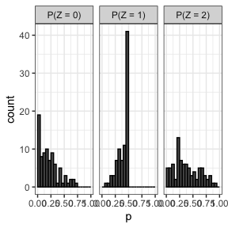

```r
(marginal_Z <- summaries_for_plots %>%
  filter(regression == "exposure") %>%
  pivot_longer(cols = starts_with("P(Z ="),
               names_to = "z", values_to = "p") %>%
  ggplot(aes(x = p)) +
    geom_histogram(boundary = 0, binwidth = 0.05,
                   color = "black") +
    facet_grid(~ z) +
    xlim(c(0,1)) +
    theme_bw())
```

```r
ggsave(
  plot = marginal_Z,
  filename = here::here("figures/example_analyses",
                        "smoking_lung_cancer_marginal_Z.png"),
  dpi = 300, width = 6.5, height = 2
)
```

Next, coefficients. Here, we see histograms of the values of $\beta_0$ (intercepts inferred) and $\beta_1$ (coefficients reported) for both logistic regressions of SNPs on exposure and outcome. We notice a gap around $0$ for $\beta_1$ in the logistic regression of the SNPs on the exposure. This is as expected, since we only want SNPs that are associated with the exposure, which means we restrict ourselves to SNPs with coefficients significantly different from $0$.

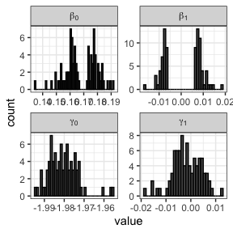

```r
(lung_cancer_coefficients <- summaries_for_plots %>%
  pivot_longer(cols = c(beta, beta0),
               names_to = "coef", values_to = "value") %>%
  mutate(real_coefs = case_when(coef == "beta" & regression == "exposure" ~ "beta[1]",
                                coef == "beta0" & regression == "exposure" ~ "beta[0]",
                                coef == "beta" & regression == "outcome" ~ "gamma[1]",
                                coef == "beta0" & regression == "outcome" ~ "gamma[0]")) %>%
  ggplot(aes(x = value)) +
    geom_histogram(boundary = 0, binwidth = 0.001,
                   color = "black") +
    facet_wrap(~ real_coefs,
               scales = "free",
               labeller = label_parsed) +
    theme_bw())
```

```r
ggsave(
  plot = lung_cancer_coefficients,
  filename = here::here("figures/example_analyses",
                        "smoking_lung_cancer_coefficients.png"),
  dpi = 300, width = 5, height = 3
)
```

Finally, we have the marginal conditionals $P(X = 1 | Z = z), z = 0,1,2$ and $P(Y = 1 | Z = z), z = 0,1,2$. We notice that the location of the histograms are about the same for the three levels of $Z$, which is the reason for all the SNPs being very weak instruments.

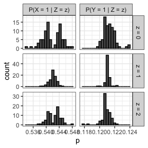

```r
(marginal_conditionals <- summaries_for_plots %>%
  pivot_longer(cols = starts_with("xy_given_z"),
               names_to = "vars", values_to = "p") %>%
  mutate(regression = if_else(regression == "exposure",
                              "P(X = 1 | Z = z)", "P(Y = 1 | Z = z)"),
         vars = paste("z =", str_extract(vars, "[0-2]"))) %>%
  ggplot(aes(x = p)) +
    geom_histogram(bins = 20, boundary = 0.2,
                   color = "black") +
    facet_grid(vars ~ regression,
               scales = "free") +
    theme_bw())
```

```r
ggsave(
  plot = marginal_conditionals,
  filename = here::here("figures/example_analyses",
                        "smoking_lung_cancer_marginal_conditionals.png"),
  dpi = 300, width = 5, height = 3
)
```

## Bound ACE using the bivariate data

Now, we calculate the bounds (both with and without assuming monotonicity of $P(X = 1 | Z = z)$) using the `get_bounds()` function.

```r
smoking_lung_cancer_bounds <- smoking_lung_cancer_w_intercept %>%
  select(-find_intercept, -beta0, -beta, -p_outcome, -ave_eaf) %>%
  mutate(regression = if_else(regression == "outcome", "gammas", "thetas")) %>%
  pivot_wider(names_from = regression, values_from = `thetas/gammas`) %>%
  rowwise() %>%
  mutate(bivariate_bounds = list(get_bounds(thetas = thetas, gammas = gammas,
                                            stop = FALSE, warning = FALSE)),
         interval = list(bivariate_bounds$interval),
         constraints_violated = bivariate_bounds$constraints_violated,
         bivariate_bounds_mono = list(get_bounds(thetas = thetas, gammas = gammas,
                                                 stop = FALSE, warning = FALSE,
                                                 x_mono = TRUE)),
         interval_mono = list(bivariate_bounds_mono$interval),
         constraints_violated_mono = bivariate_bounds_mono$constraints_violated) %>%
  ungroup() %>%
  unnest_wider(col = interval_mono) %>%
  rename(upper_mono = upper, lower_mono = lower) %>%
  unnest_wider(interval)
```

The bivariate bounds obtained from the 84 SNPs are shown on the following plot. As can be seen, none of the bounds provide much information at all, and all intervals are rather wide.

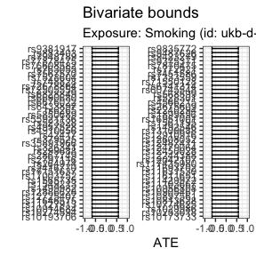

```r
smoking_lung_cancer_bivariate_bounds <- smoking_lung_cancer_bounds %>%
  arrange(lower) %>%
  ggplot(aes(y = SNP)) +
    geom_errorbar(aes(xmax = upper, xmin = lower)) +
    theme_bw() +
    facet_wrap(~ lower < median(lower),
               ncol = 2, scales = "free_y") +
    theme(strip.text = element_blank(),
          strip.background = element_blank()) +
    labs(
      y = "",
      x = "ATE"
    ) +
    lims(x = c(-1, 1))

smoking_lung_cancer_bivariate_bounds +
      labs(title = "Bivariate bounds",
         subtitle = paste0("Exposure: Smoking (id: ", smoking_experiment$id, "). ",
                           "Outcome: Lung Cancer (id: ", lung_cancer_experiment$id, ")."))
```

```r
ggsave(
  plot = smoking_lung_cancer_bivariate_bounds,
  filename = here::here("figures/example_analyses",
                        paste0("smoking_lung_cancer_bivariate_bounds_", smoking_experiment$id, "_", lung_cancer_experiment$id,".png")),
  width = 8, height = 10, dpi = 300
)
```

We save a figure with just a subset of the bounds to be included in the main manuscript.

```r
smoking_SNP_subset <- unique(smoking_lung_cancer_bounds$SNP)[c(2, 5, 17, 25, 34, 52, 65, 78)]

smoking_lung_cancer_bivariate_bounds_subset <- smoking_lung_cancer_bounds %>%
  filter(SNP %in% smoking_SNP_subset) %>%
  arrange(lower) %>%
  ggplot(aes(y = SNP)) +
    geom_errorbar(aes(xmax = upper, xmin = lower)) +
    theme_bw() +
    theme(strip.text = element_blank(),
          strip.background = element_blank()) +
    labs(
      y = "",
      x = "ATE"
    ) +
    lims(x = c(-1, 1))

ggsave(
  plot = smoking_lung_cancer_bivariate_bounds_subset,
  filename = here::here("figures/example_analyses",
                        paste0("smoking_lung_cancer_bivariate_bounds_subset_", smoking_experiment$id, "_", lung_cancer_experiment$id,".png")),
  width = 4, height = 4, dpi = 300
)
```

That all the bounds are rather wide is no surprise – all the IVs are rather weak, as can be seen on the histogram of the strengths below.

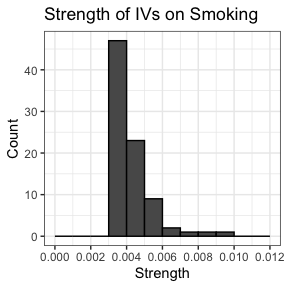

```r
strength_histogram <- smoking_lung_cancer_bounds %>%
  rowwise() %>%
  mutate(strength = max(abs(outer(thetas, thetas, `-`)))) %>%
  ungroup() %>%
  ggplot(aes(x = strength)) +
    geom_histogram(color = "black", binwidth = 0.001, boundary = 0) +
    scale_x_continuous(limits = c(0, 0.012),
                       breaks = seq(0, 0.012, by = 0.002)) +
    labs(x = "Strength", y = "Count") +
    theme_bw()

strength_histogram +
  labs(title = "Strength of IVs on Smoking")
```

```r
ggsave(
  plot = strength_histogram,
  filename = here::here("figures/example_analyses",
                        "strength_histogram.png"),
  dpi = 300, width = 8, height = 4
)
```

## Random Sampling of Potential Joint Distributions

To try to squeeze more information out of the data at hand, we try to randomly sample distributions $P(Y = y, X = x | Z = z)$ that match the marginals we have, and don’t violate the IV model.

Using the function `potential_covs()`, we get constraints on the values of $\text{Cov}(X,Y | Z = z)$. Feeding these constraints to `sample_joint_probs()`, we sample $500$ joint distributions for each SNP. (Note: we save the results to a file so we can recompile this document much more efficiently.)

```r
smoking_lung_cancer_filename <- paste0("samples_of_joints_", smoking_experiment$id, "_", lung_cancer_experiment$id, ".Rds")

if(file.exists(here::here("vignettes_data/example_analyses", smoking_lung_cancer_filename))){
  smoking_lung_cancer_samples_of_joints <- read_rds(here::here("vignettes_data/example_analyses", smoking_lung_cancer_filename))
} else {
  set.seed(7892312)

  smoking_lung_cancer_samples_of_joints <- smoking_lung_cancer_bounds %>%
    rowwise() %>%
    mutate(pot_covs = list(potential_covs(thetas = thetas, gammas = gammas)),
           sample_joint = list(sample_joint_probs(pot_covs, n = 500, return_bounds = TRUE)))

  write_rds(smoking_lung_cancer_samples_of_joints, here::here("vignettes_data/example_analyses", smoking_lung_cancer_filename))
}
```

We do some expanding to expose the bounds from these joint distributions.

```r
smoking_lung_cancer_trivariate_bounds <- smoking_lung_cancer_samples_of_joints %>%
  ungroup() %>%
  select(SNP, bivariate_lower = lower, bivariate_upper = upper, sample_joint) %>%
  unnest(sample_joint) %>%
  unnest(joint) %>%
  unnest_wider(bounds) %>%
  mutate(contains_zero = lower < 0 & upper > 0)
```

The plot below shows all bounds obtained from sampled joint distributions along with the original bivariate bounds. In this particular example, having a dataset with observations of $(X,Y,Z)$ would not provide much more information. There seems to be essentially no setting where the IV model holds, the marginals we observe are correct, AND the joint distribution would allow to determine direction of the ACE.

[figure not shown]

```r
smoking_lung_cancer_individual_SNPs_plot <- smoking_lung_cancer_trivariate_bounds %>%
  group_by(SNP) %>%
  arrange(lower) %>%
  mutate(id = row_number()) %>%
  ungroup() %>%
  ggplot(aes(y = id, color = contains_zero)) +
    geom_vline(aes(xintercept = bivariate_lower),
               linetype = "dashed") +
    geom_vline(aes(xintercept = bivariate_upper),
               linetype = "dashed") +
    geom_vline(xintercept = 0) +
    geom_errorbar(aes(xmin = lower,
                      xmax = upper)) +
    geom_point(data = data.frame(x = 0, y = 10,
                                 contains_zero = FALSE),
               aes(x = x, y = y),
               alpha = 0) +
    scale_color_manual("",
                       values = c("grey50", "red4"),
                       labels = c("Overlaps Zero", "Does not Overlap Zero"),
                       breaks = c("TRUE", "FALSE"),
                       drop = FALSE) +
    lims(x = c(-1, 1)) +
    labs(
        x = "ATE", y = ""
    ) +
    coord_fixed(ratio = 1/350) +
    facet_wrap(~SNP, ncol = 12) +
    theme(legend.position = "top",
          axis.text.y = element_blank(),
          axis.ticks.y = element_blank(),
          axis.text.x = element_text(angle = 45, hjust = 1),
          axis.ticks.x = element_line())

smoking_lung_cancer_individual_SNPs_plot +
    labs(title = "Possible Trivariate Bounds from Bivariate Data",
         subtitle = paste0("Exposure: Smoking (id: ", smoking_experiment$id, "). ",
                           "Outcome: Lung Cancer (id: ", lung_cancer_experiment$id, ")."))
```

```r
ggsave(
  plot = smoking_lung_cancer_individual_SNPs_plot,
  filename = here::here("figures/example_analyses",
                        paste0("smoking_lung_cancer_individual_SNPs_plot_", smoking_experiment$id, "_", lung_cancer_experiment$id,".png")),
  height = 7, width = 10, dpi = 300
)
```

Again, we save figure with only a subset of the SNPs for our manuscript:

```r
smoking_lung_cancer_individual_SNPs_plot_subset <- smoking_lung_cancer_trivariate_bounds %>%
  filter(SNP %in% smoking_SNP_subset) %>%
  group_by(SNP) %>%
  arrange(lower) %>%
  mutate(id = row_number()) %>%
  ungroup() %>%
  ggplot(aes(y = id, color = contains_zero)) +
    geom_errorbar(aes(xmin = lower,
                      xmax = upper)) +
    geom_point(data = data.frame(x = 0, y = 10,
                                 contains_zero = FALSE),
               aes(x = x, y = y),
               alpha = 0) +
    geom_vline(aes(xintercept = bivariate_lower),
               linetype = "dashed") +
    geom_vline(aes(xintercept = bivariate_upper),
               linetype = "dashed") +
    geom_vline(xintercept = 0) +
    scale_color_manual("",
                       values = c("grey50", "red4"),
                       labels = c("Overlaps Zero", "Does not Overlap Zero"),
                       breaks = c("TRUE", "FALSE"),
                       drop = FALSE) +
    lims(x = c(-1, 1)) +
    labs(
        x = "ATE", y = ""
    ) +
    coord_fixed(ratio = 1/350) +
    facet_wrap(~SNP, ncol = 2) +
    theme(legend.position = "top",
          axis.text.y = element_blank(),
          axis.ticks.y = element_blank(),
          axis.text.x = element_text(),
          axis.ticks.x = element_line())

ggsave(
  plot = smoking_lung_cancer_individual_SNPs_plot_subset,
  filename = here::here("figures/example_analyses",
                        paste0("smoking_lung_cancer_individual_SNPs_plot_subset_", smoking_experiment$id, "_", lung_cancer_experiment$id,".png")),
  width = 4, height = 6, dpi = 300
)
```

Below is a similar plot where we assume monotonicity of $P(X = 1 | Z = z)$. This is only done in cases where the marginals are such that the bivariate constraints are not violated. We notice that the information in these bounds is not much different.

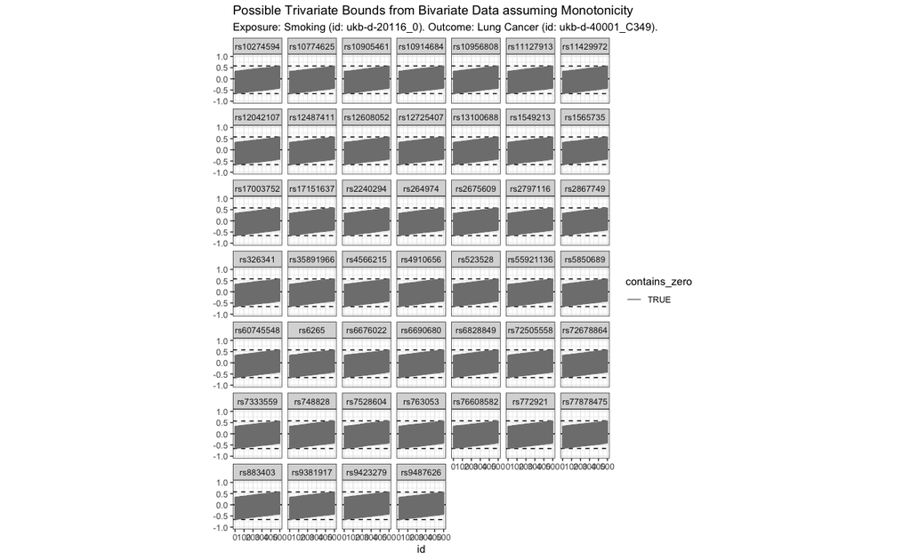

```r
smoking_lung_cancer_filename_mono <- paste0("samples_of_joints_mono_", smoking_experiment$id, "_", lung_cancer_experiment$id, ".Rds")

if(file.exists(here::here("vignettes_data/example_analyses", smoking_lung_cancer_filename_mono))){
  smoking_lung_cancer_samples_of_joints_mono <- read_rds(here::here("vignettes_data/example_analyses",
                                                                   smoking_lung_cancer_filename_mono))
} else {
  set.seed(6925896)
  smoking_lung_cancer_samples_of_joints_mono <- smoking_lung_cancer_bounds %>%
    filter(!constraints_violated_mono) %>%
    mutate(i = row_number()) %>%
    rowwise() %>%
    mutate(pot_covs = list(potential_covs(thetas = thetas, gammas = gammas, x_mono = TRUE)),
           sample_joint = list(sample_joint_probs(pot_covs, n = 500, return_bounds = TRUE,
                                                  x_mono = TRUE, print_progress = FALSE,
                                                  print_as_progress = NULL)))

  write_rds(smoking_lung_cancer_samples_of_joints_mono,
            here::here("vignettes_data/example_analyses",
                       smoking_lung_cancer_filename_mono))
}

smoking_lung_cancer_trivariate_mono_bounds <- smoking_lung_cancer_samples_of_joints_mono %>%
  ungroup() %>%
  select(SNP, bivariate_lower = lower_mono, bivariate_upper = upper_mono, sample_joint) %>%
  unnest(sample_joint) %>%
  unnest(joint) %>%
  unnest_wider(bounds) %>%
  mutate(contains_zero = lower < 0 & upper > 0)

smoking_lung_cancer_individual_SNPs_mono_plot <- smoking_lung_cancer_trivariate_mono_bounds %>%
  group_by(SNP) %>%
  arrange(lower) %>%
  mutate(id = row_number()) %>%
  ungroup() %>%
  ggplot(aes(x = id)) +
    geom_hline(aes(yintercept = bivariate_lower),
               linetype = "dashed") +
    geom_hline(aes(yintercept = bivariate_upper),
               linetype = "dashed") +
    geom_hline(yintercept = 0) +
    geom_errorbar(aes(ymin = lower,
                      ymax = upper,
                      color = contains_zero)) +
    scale_color_manual(values = c("red4", "grey50"),
                       breaks = c(FALSE, TRUE)) +
    lims(y = c(-1, 1)) +
    coord_fixed(ratio = 500/2) +
    facet_wrap(~SNP, nrow = 7) +
    labs(title = "Possible Trivariate Bounds from Bivariate Data assuming Monotonicity",
         subtitle = paste0("Exposure: Smoking (id: ", smoking_experiment$id, "). ",
                           "Outcome: Lung Cancer (id: ", lung_cancer_experiment$id, ")."))

smoking_lung_cancer_individual_SNPs_mono_plot
```

## Intersections of Bounds from Randomly Sampled Joint Distributions

First, we create a tibble with all unique pairs of SNPs.

```r
smoking_lung_cancer_pairs_of_snps <- expand_grid(SNP1 = unique(smoking_lung_cancer_trivariate_bounds$SNP),
                                                 SNP2 = unique(smoking_lung_cancer_trivariate_bounds$SNP)) %>%
  filter(SNP1 != SNP2) %>%
  rowwise() %>%
  summarize(SNPs = list(sort(c(SNP1, SNP2)))) %>%
  filter(duplicated(SNPs)) %>%
  mutate(SNPs = map(SNPs, ~tibble_row(SNP1 = .x[1], SNP2 = .x[2]))) %>%
  unnest_wider(SNPs)
```

```
## `summarise()` has ungrouped output. You can override using the `.groups` argument.
```

```r
smoking_lung_cancer_pairs_of_snps
```

```
## # A tibble: 3,486 x 2
##    SNP1       SNP2
##    <chr>      <chr>
##  1 rs10173733 rs10193706
##  2 rs10173733 rs10233018
##  3 rs10193706 rs10233018
##  4 rs10173733 rs10274594
##  5 rs10193706 rs10274594
##  6 rs10233018 rs10274594
##  7 rs10173733 rs1029986
##  8 rs10193706 rs1029986
##  9 rs10233018 rs1029986
## 10 rs10274594 rs1029986
## # … with 3,476 more rows
```

The resulting tibble has 3486 rows, which is exactly ${84 \choose 2}$.

It is not feasible (and probably not even useful…) to go through all pairs, so instead we will simply look at a random sample of 8 pairs.

```r
set.seed(493637)

smoking_lung_cancer_chosen_pairs <- smoking_lung_cancer_pairs_of_snps %>%
  sample_n(8)

pander::pander(smoking_lung_cancer_chosen_pairs)
```

| SNP1 | SNP2 |
| --- | --- |
| rs528301 | rs7451586 |
| rs17151637 | rs6265 |
| rs1549213 | rs17151637 |
| rs11127913 | rs12725407 |
| rs12910916 | rs76608582 |
| rs4566215 | rs7528604 |
| rs6141314 | rs883403 |
| rs2867749 | rs9381917 |

We simply reuse the joint distributions and bounds found previously noting that this imposes the assumption that the distributions of $(X,Y|Z_1)$ and $(X,Y|Z_2)$ are independent of each other.

```r
smoking_lung_cancer_both_bounds <- smoking_lung_cancer_chosen_pairs %>%
  rowwise() %>%
  mutate(
    SNP1_bounds = list(
      smoking_lung_cancer_trivariate_bounds %>%
        filter(SNP == SNP1) %>%
        select(SNP1_bivariate_lower = bivariate_lower, SNP1_bivariate_upper = bivariate_upper,
               SNP1_lower = lower, SNP1_upper = upper)
    ),
    SNP2_bounds = list(
      smoking_lung_cancer_trivariate_bounds %>%
        filter(SNP == SNP2) %>%
        select(SNP2_bivariate_lower = bivariate_lower, SNP2_bivariate_upper = bivariate_upper,
               SNP2_lower = lower, SNP2_upper = upper)
    )
  ) %>%
  ungroup() %>%
  unnest(cols = c(SNP1_bounds, SNP2_bounds))

smoking_lung_cancer_both_bounds
```

```
## # A tibble: 4,000 x 10
##    SNP1  SNP2  SNP1_bivariate_… SNP1_bivariate_… SNP1_lower SNP1_upper
##    <chr> <chr>            <dbl>            <dbl>      <dbl>      <dbl>
##  1 rs52… rs74…           -0.662            0.576     -0.468      0.405
##  2 rs52… rs74…           -0.662            0.576     -0.456      0.419
##  3 rs52… rs74…           -0.662            0.576     -0.433      0.370
##  4 rs52… rs74…           -0.662            0.576     -0.499      0.425
##  5 rs52… rs74…           -0.662            0.576     -0.461      0.358
##  6 rs52… rs74…           -0.662            0.576     -0.484      0.415
##  7 rs52… rs74…           -0.662            0.576     -0.459      0.459
##  8 rs52… rs74…           -0.662            0.576     -0.477      0.357
##  9 rs52… rs74…           -0.662            0.576     -0.504      0.396
## 10 rs52… rs74…           -0.662            0.576     -0.429      0.386
## # … with 3,990 more rows, and 4 more variables: SNP2_bivariate_lower <dbl>,
## #   SNP2_bivariate_upper <dbl>, SNP2_lower <dbl>, SNP2_upper <dbl>
```

Finally, we construct intersection bounds.

```r
smoking_lung_cancer_intersection_bounds <- smoking_lung_cancer_both_bounds %>%
  rowwise() %>%
  mutate(intersection_lower = max(SNP1_lower, SNP2_lower),
         intersection_upper = min(SNP1_upper, SNP2_upper),
         bivariate_intersection_lower = max(SNP1_bivariate_lower, SNP2_bivariate_lower),
         bivariate_intersection_upper = min(SNP1_bivariate_upper, SNP2_bivariate_upper),
  ) %>%
  ungroup() %>%
  mutate(contains_zero = intersection_lower < 0 & intersection_upper > 0)
```

A plot to display them.

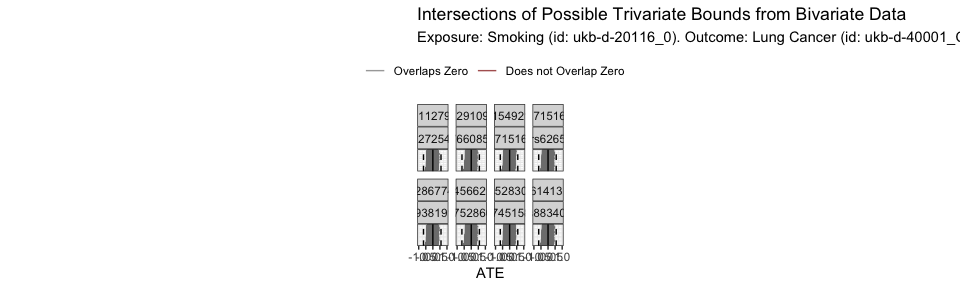

```r
smoking_lung_cancer_intersection_bounds_plot <- smoking_lung_cancer_intersection_bounds %>%
  group_by(SNP1, SNP2) %>%
  arrange(intersection_lower) %>%
  mutate(i = row_number()) %>%
  ungroup() %>%
  ggplot(aes(y = i)) +
    geom_vline(aes(xintercept = bivariate_intersection_lower),
               linetype = "dashed") +
    geom_vline(aes(xintercept = bivariate_intersection_upper),
               linetype = "dashed") +
    geom_errorbar(aes(xmin = intersection_lower,
                      xmax = intersection_upper,
                      color = contains_zero),
                  alpha = 0.7) +
    geom_point(data = data.frame(x = 0, y = 10,
                                 contains_zero = FALSE),
               aes(x = x, y = y, color = contains_zero),
               alpha = 0) +
    scale_color_manual("",
                       values = c("grey50", "red4"),
                       labels = c("Overlaps Zero", "Does not Overlap Zero"),
                       breaks = c("TRUE", "FALSE"),
                       drop = FALSE) +
    lims(x = c(-1, 1)) +
    coord_fixed(ratio = 1/350) +
    geom_vline(xintercept = 0) +
    facet_wrap(~SNP1 + SNP2,
               nrow = 2) +
    labs(
      y = "", x = "ATE"
    ) +
    theme_bw() +
    theme(legend.position = "top",
          axis.text.x = element_text(),
          axis.ticks.x = element_line(),
          axis.text.y = element_blank(),
          axis.ticks.y = element_blank())

ggsave(
  plot = smoking_lung_cancer_intersection_bounds_plot,
  filename = here::here("figures/example_analyses",
                        paste0("smoking_lung_cancer_intersection_bounds_plot_", smoking_experiment$id, "_", lung_cancer_experiment$id,".png")),
  width = 8, height = 6, dpi = 300
)


smoking_lung_cancer_intersection_bounds_plot +
    labs(title = "Intersections of Possible Trivariate Bounds from Bivariate Data",
         subtitle = paste0("Exposure: Smoking (id: ", smoking_experiment$id, "). ",
                           "Outcome: Lung Cancer (id: ", lung_cancer_experiment$id, ")."))
```

# Effect of High Cholesterol on Heart Attack

Our second example will use high cholesterol as exposure, and heart attack as outcome (both as binary). The following repeat the analysis above for this pair of variables.

## Collect Data

```r
cholesterol_experiment <- ao %>% filter(id == "ukb-a-108")
cholesterol_instruments <- extract_instruments(cholesterol_experiment$id)

heart_attack_experiment <- ao %>% filter(id == "ukb-a-434")

heart_attack_data <- extract_outcome_data(snps = cholesterol_instruments$SNP, outcomes = heart_attack_experiment$id)
```

```
## Extracting data for 54 SNP(s) from 1 GWAS(s)
```

```r
cholesterol_heart_attack_harmonized <- harmonise_data(cholesterol_instruments, heart_attack_data) %>% as_tibble()
```

```
## Harmonising Non-cancer illness code  self-reported: high cholesterol || id:ukb-a-108 (ukb-a-108) and Vascular/heart problems diagnosed by doctor: Heart attack || id:ukb-a-434 (ukb-a-434)
```

```
## Removing the following SNPs for being palindromic with intermediate allele frequencies:
## rs28601761, rs7213086
```

```r
cholesterol_heart_attack_pop_probs <- tibble(regression = c("outcome", "exposure"),
                                             p_outcome = c(cholesterol_experiment  %$% { ncase / (ncase + ncontrol) },
                                                           heart_attack_experiment %$% { ncase / (ncase + ncontrol) }))

cholesterol_heart_attack_prep_for_bounds <- cholesterol_heart_attack_harmonized %>%
  rowwise() %>%
  mutate(samplesize.exposure = cholesterol_experiment$ncase + cholesterol_experiment$ncontrol,
         samplesize.outcome = heart_attack_experiment$ncase + heart_attack_experiment$ncontrol,
         ave_eaf = weighted.mean(x = c_across(c(eaf.exposure, eaf.outcome)),
                                 w = c_across(c(samplesize.exposure, samplesize.outcome)))) %>%
  select(SNP, contains("beta"), ave_eaf) %>%
  pivot_longer(contains("beta")) %>%
  separate(name, into = c("variable", "regression"), sep = "\\.") %>%
  pivot_wider(names_from = variable, values_from = value) %>%
  mutate(`P(Z = 2)` = (1 - ave_eaf)^2,
         `P(Z = 1)` = 2*ave_eaf*(1 - ave_eaf),
         `P(Z = 0)` = ave_eaf^2)

cholesterol_heart_attack_w_intercept <- cholesterol_heart_attack_prep_for_bounds %>%
  left_join(cholesterol_heart_attack_pop_probs) %>%
  rowwise() %>%
  mutate(find_intercept = list(find_intercept(beta1 = beta,
                                              p_outcome = p_outcome,
                                              pz = c(`P(Z = 0)`, `P(Z = 1)`, `P(Z = 2)`),
                                              interval = c(-7,7))),
         beta0 = find_intercept$root,
         `thetas/gammas` = list(1/(1+exp(-beta0 - 0:2*beta))))
```

## Summaries of Marginal Distributions

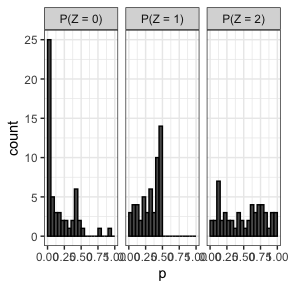

```r
summaries_for_plots_cholesterol_HA <- cholesterol_heart_attack_w_intercept %>%
  ungroup() %>%
  select(SNP, regression, beta, starts_with("P(Z ="), p_outcome, beta0, `thetas/gammas`) %>%
  mutate(`thetas/gammas` = map(`thetas/gammas`, ~setNames(.x, c("xy_given_z0", "xy_given_z1", "xy_given_z2")))) %>%
  unnest_wider(`thetas/gammas`)

write_csv(
  summaries_for_plots_cholesterol_HA,
  here::here("vignettes_data/summary_stats_cholesterol_on_heart_attack.csv")
)

(marginal_Z_cholesterol_HA <- summaries_for_plots_cholesterol_HA %>%
  filter(regression == "exposure") %>%
  pivot_longer(cols = starts_with("P(Z ="),
               names_to = "z", values_to = "p") %>%
  ggplot(aes(x = p)) +
    geom_histogram(boundary = 0, binwidth = 0.05,
                   color = "black") +
    facet_grid(~ z) +
    xlim(c(0,1)) +
    theme_bw())
```

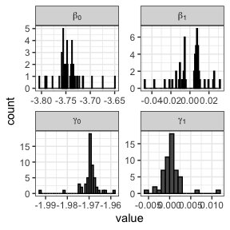

```r
ggsave(
  plot = marginal_Z_cholesterol_HA,
  filename = here::here("figures/example_analyses",
                        "cholesterol_heart_attack_marginal_Z.png"),
  dpi = 300, width = 6.5, height = 2
)

(heart_attack_coefficients <- summaries_for_plots_cholesterol_HA %>%
  pivot_longer(cols = c(beta, beta0),
               names_to = "coef", values_to = "value") %>%
  mutate(real_coefs = case_when(coef == "beta" & regression == "exposure" ~ "beta[1]",
                                coef == "beta0" & regression == "exposure" ~ "beta[0]",
                                coef == "beta" & regression == "outcome" ~ "gamma[1]",
                                coef == "beta0" & regression == "outcome" ~ "gamma[0]")) %>%
  ggplot(aes(x = value)) +
    geom_histogram(boundary = 0, binwidth = 0.001,
                   color = "black") +
    facet_wrap(~ real_coefs,
               scales = "free",
               labeller = label_parsed) +
    theme_bw())
```

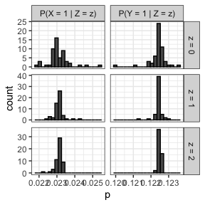

```r
ggsave(
  plot = heart_attack_coefficients,
  filename = here::here("figures/example_analyses",
                        "cholesterol_heart_attack_coefficients.png"),
  dpi = 300, width = 5, height = 3
)

(cholesterol_heart_attack_marginal_conditionals <- summaries_for_plots_cholesterol_HA %>%
  pivot_longer(cols = starts_with("xy_given_z"),
               names_to = "vars", values_to = "p") %>%
  mutate(regression = if_else(regression == "exposure",
                              "P(X = 1 | Z = z)", "P(Y = 1 | Z = z)"),
         vars = paste("z =", str_extract(vars, "[0-2]"))) %>%
  ggplot(aes(x = p)) +
    geom_histogram(bins = 20, boundary = 0.2,
                   color = "black") +
    facet_grid(vars ~ regression,
               scales = "free") +
    theme_bw())
```

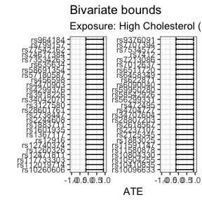

```r
ggsave(
  plot = cholesterol_heart_attack_marginal_conditionals,
  filename = here::here("figures/example_analyses",
                        "cholesterol_heart_attack_marginal_conditionals.png"),
  dpi = 300, width = 5, height = 3
)

cholesterol_heart_attack_bounds <- cholesterol_heart_attack_w_intercept %>%
  select(-find_intercept, -beta0, -beta, -p_outcome, -ave_eaf) %>%
  mutate(regression = if_else(regression == "outcome", "gammas", "thetas")) %>%
  pivot_wider(names_from = regression, values_from = `thetas/gammas`) %>%
  rowwise() %>%
  mutate(bivariate_bounds = list(get_bounds(thetas = thetas, gammas = gammas,
                                            stop = FALSE, warning = FALSE)),
         interval = list(bivariate_bounds$interval),
         constraints_violated = bivariate_bounds$constraints_violated,
         bivariate_bounds_mono = list(get_bounds(thetas = thetas, gammas = gammas,
                                                 stop = FALSE, warning = FALSE,
                                                 x_mono = TRUE)),
         interval_mono = list(bivariate_bounds_mono$interval),
         constraints_violated_mono = bivariate_bounds_mono$constraints_violated) %>%
  ungroup() %>%
  unnest_wider(col = interval_mono) %>%
  rename(upper_mono = upper, lower_mono = lower) %>%
  unnest_wider(interval)

cholesterol_heart_attack_bivariate_bounds <- cholesterol_heart_attack_bounds %>%
  arrange(lower) %>%
  ggplot(aes(y = SNP)) +
    geom_errorbar(aes(xmax = upper, xmin = lower)) +
    theme_bw() +
    facet_wrap(~ lower < median(lower),
               ncol = 2, scales = "free_y") +
    theme(strip.text = element_blank(),
          strip.background = element_blank()) +
    labs(
      y = "",
      x = "ATE"
    ) +
    lims(x = c(-1, 1))

cholesterol_heart_attack_bivariate_bounds +
      labs(title = "Bivariate bounds",
         subtitle = paste0("Exposure: High Cholesterol (id: ", cholesterol_experiment$id, "). ",
                           "Outcome: Heart Attack (id: ", heart_attack_experiment$id, ")."))
```

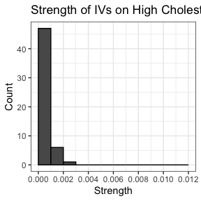

```r
ggsave(
  plot = cholesterol_heart_attack_bivariate_bounds,
  filename = here::here("figures/example_analyses",
                        paste0("cholesterol_heart_attack_bivariate_bounds_", cholesterol_experiment$id, "_", heart_attack_experiment$id,".png")),
  width = 8, height = 10, dpi = 300
)

cholesterol_SNP_subset <- unique(cholesterol_heart_attack_bounds$SNP)[c(2, 5, 12, 17, 25, 34, 45, 52)]

cholesterol_heart_attack_bivariate_bounds_subset <- cholesterol_heart_attack_bounds %>%
  filter(SNP %in% cholesterol_SNP_subset) %>%
  arrange(lower) %>%
  ggplot(aes(y = SNP)) +
    geom_errorbar(aes(xmax = upper, xmin = lower)) +
    theme_bw() +
    theme(strip.text = element_blank(),
          strip.background = element_blank()) +
    labs(
      y = "",
      x = "ATE"
    ) +
    lims(x = c(-1, 1))

ggsave(
  plot = cholesterol_heart_attack_bivariate_bounds_subset,
  filename = here::here("figures/example_analyses",
                        paste0("cholesterol_heart_attack_bivariate_bounds_subset_", cholesterol_experiment$id, "_", heart_attack_experiment$id,".png")),
  width = 4, height = 4, dpi = 300
)

strength_histogram_cholesterol <- cholesterol_heart_attack_bounds %>%
  rowwise() %>%
  mutate(strength = max(abs(outer(thetas, thetas, `-`)))) %>%
  ungroup() %>%
  ggplot(aes(x = strength)) +
    geom_histogram(color = "black", binwidth = 0.001, boundary = 0) +
    scale_x_continuous(limits = c(0, 0.012),
                       breaks = seq(0, 0.012, by = 0.002)) +
    labs(x = "Strength", y = "Count") +
    theme_bw()

strength_histogram_cholesterol +
  labs(title = "Strength of IVs on High Cholesterol")
```

```r
ggsave(
  plot = strength_histogram_cholesterol,
  filename = here::here("figures/example_analyses",
                        "cholesterol_heart_attack_strength_histogram.png"),
  dpi = 300, width = 8, height = 4
)
```

## Random Sampling of Potential Joint Distributions

[figure not shown]

```r
cholesterol_heart_attack_filename <- paste0("samples_of_joints_", cholesterol_experiment$id, "_", heart_attack_experiment$id, ".Rds")

if(file.exists(here::here("vignettes_data/example_analyses", cholesterol_heart_attack_filename))){
  cholesterol_heart_attack_samples_of_joints <- read_rds(here::here("vignettes_data/example_analyses", cholesterol_heart_attack_filename))
} else {
  set.seed(7892312)

  cholesterol_heart_attack_samples_of_joints <- cholesterol_heart_attack_bounds %>%
    rowwise() %>%
    mutate(pot_covs = list(potential_covs(thetas = thetas, gammas = gammas)),
           sample_joint = list(sample_joint_probs(pot_covs, n = 500, return_bounds = TRUE)))

  write_rds(cholesterol_heart_attack_samples_of_joints, here::here("vignettes_data/example_analyses", cholesterol_heart_attack_filename))
}

cholesterol_heart_attack_trivariate_bounds <- cholesterol_heart_attack_samples_of_joints %>%
  ungroup() %>%
  select(SNP, bivariate_lower = lower, bivariate_upper = upper, sample_joint) %>%
  unnest(sample_joint) %>%
  unnest(joint) %>%
  unnest_wider(bounds) %>%
  mutate(contains_zero = lower < 0 & upper > 0)

cholesterol_heart_attack_individual_SNPs_plot <- cholesterol_heart_attack_trivariate_bounds %>%
  group_by(SNP) %>%
  arrange(lower) %>%
  mutate(id = row_number()) %>%
  ungroup() %>%
  ggplot(aes(y = id, color = contains_zero)) +
    geom_vline(aes(xintercept = bivariate_lower),
               linetype = "dashed") +
    geom_vline(aes(xintercept = bivariate_upper),
               linetype = "dashed") +
    geom_vline(xintercept = 0) +
    geom_errorbar(aes(xmin = lower,
                      xmax = upper)) +
    geom_point(data = data.frame(x = 0, y = 10,
                                 contains_zero = FALSE),
               aes(x = x, y = y),
               alpha = 0) +
    scale_color_manual("",
                       values = c("grey50", "red4"),
                       labels = c("Overlaps Zero", "Does not Overlap Zero"),
                       breaks = c("TRUE", "FALSE"),
                       drop = FALSE) +
    lims(x = c(-1, 1)) +
    labs(
        x = "ATE", y = ""
    ) +
    coord_fixed(ratio = 1/350) +
    facet_wrap(~SNP, ncol = 12) +
    theme(legend.position = "top",
          axis.text.y = element_blank(),
          axis.ticks.y = element_blank(),
          axis.text.x = element_text(angle = 45, hjust = 1),
          axis.ticks.x = element_line())

cholesterol_heart_attack_individual_SNPs_plot +
    labs(title = "Possible Trivariate Bounds from Bivariate Data",
         subtitle = paste0("Exposure: High Cholesterol (id: ", cholesterol_experiment$id, "). ",
                           "Outcome: Heart Attack (id: ", heart_attack_experiment$id, ")."))
```

[figure not shown]

```r
ggsave(
  plot = cholesterol_heart_attack_individual_SNPs_plot,
  filename = here::here("figures/example_analyses",
                        paste0("cholesterol_heart_attack_individual_SNPs_plot_", cholesterol_experiment$id, "_", heart_attack_experiment$id,".png")),
  height = 5.5, width = 10, dpi = 300
)

cholesterol_heart_attack_individual_SNPs_plot_subset <- cholesterol_heart_attack_trivariate_bounds %>%
  filter(SNP %in% cholesterol_SNP_subset) %>%
  group_by(SNP) %>%
  arrange(lower) %>%
  mutate(id = row_number()) %>%
  ungroup() %>%
  ggplot(aes(y = id, color = contains_zero)) +
    geom_errorbar(aes(xmin = lower,
                      xmax = upper)) +
    geom_point(data = data.frame(x = 0, y = 10,
                                 contains_zero = FALSE),
               aes(x = x, y = y),
               alpha = 0) +
    geom_vline(aes(xintercept = bivariate_lower),
               linetype = "dashed") +
    geom_vline(aes(xintercept = bivariate_upper),
               linetype = "dashed") +
    geom_vline(xintercept = 0) +
    scale_color_manual("",
                       values = c("grey50", "red4"),
                       labels = c("Overlaps Zero", "Does not Overlap Zero"),
                       breaks = c("TRUE", "FALSE"),
                       drop = FALSE) +
    lims(x = c(-1, 1)) +
    labs(
        x = "ATE", y = ""
    ) +
    coord_fixed(ratio = 1/350) +
    facet_wrap(~SNP, ncol = 2) +
    theme(legend.position = "top",
          axis.text.y = element_blank(),
          axis.ticks.y = element_blank(),
          axis.text.x = element_text(),
          axis.ticks.x = element_line())

ggsave(
  plot = cholesterol_heart_attack_individual_SNPs_plot_subset,
  filename = here::here("figures/example_analyses",
                        paste0("cholesterol_heart_attack_individual_SNPs_plot_subset_", cholesterol_experiment$id, "_", heart_attack_experiment$id,".png")),
  width = 4, height = 6, dpi = 300
)

cholesterol_heart_attack_filename_mono <- paste0("samples_of_joints_mono_", smoking_experiment$id, "_", lung_cancer_experiment$id, ".Rds")

if(file.exists(here::here("vignettes_data/example_analyses", cholesterol_heart_attack_filename_mono))){
  cholesterol_heart_attack_samples_of_joints_mono <- read_rds(here::here("vignettes_data/example_analyses",
                                                                   cholesterol_heart_attack_filename_mono))
} else {
  set.seed(6925896)
  cholesterol_heart_attack_samples_of_joints_mono <- cholesterol_heart_attack_bounds %>%
    filter(!constraints_violated_mono) %>%
    mutate(i = row_number()) %>%
    rowwise() %>%
    mutate(pot_covs = list(potential_covs(thetas = thetas, gammas = gammas, x_mono = TRUE)),
           sample_joint = list(sample_joint_probs(pot_covs, n = 500, return_bounds = TRUE,
                                                  x_mono = TRUE, print_progress = FALSE,
                                                  print_as_progress = NULL)))

  write_rds(cholesterol_heart_attack_samples_of_joints_mono,
            here::here("vignettes_data/example_analyses",
                       cholesterol_heart_attack_filename_mono))
}

cholesterol_heart_attack_trivariate_mono_bounds <- cholesterol_heart_attack_samples_of_joints_mono %>%
  ungroup() %>%
  select(SNP, bivariate_lower = lower_mono, bivariate_upper = upper_mono, sample_joint) %>%
  unnest(sample_joint) %>%
  unnest(joint) %>%
  unnest_wider(bounds) %>%
  mutate(contains_zero = lower < 0 & upper > 0)

cholesterol_heart_attack_individual_SNPs_mono_plot <- cholesterol_heart_attack_trivariate_mono_bounds %>%
  group_by(SNP) %>%
  arrange(lower) %>%
  mutate(id = row_number()) %>%
  ungroup() %>%
  ggplot(aes(x = id)) +
    geom_hline(aes(yintercept = bivariate_lower),
               linetype = "dashed") +
    geom_hline(aes(yintercept = bivariate_upper),
               linetype = "dashed") +
    geom_hline(yintercept = 0) +
    geom_errorbar(aes(ymin = lower,
                      ymax = upper,
                      color = contains_zero)) +
    scale_color_manual(values = c("red4", "grey50"),
                       breaks = c(FALSE, TRUE)) +
    lims(y = c(-1, 1)) +
    coord_fixed(ratio = 500/2) +
    facet_wrap(~SNP, nrow = 7) +
    labs(title = "Possible Trivariate Bounds from Bivariate Data assuming Monotonicity",
         subtitle = paste0("Exposure: High Cholesterol (id: ", cholesterol_experiment$id, "). ",
                           "Outcome: Heart Attack (id: ", heart_attack_experiment$id, ")."))

cholesterol_heart_attack_individual_SNPs_mono_plot
```

## Intersections of Bounds from Randomly Sampled Joint Distributions

```r
cholesterol_heart_attack_pairs_of_snps <- expand_grid(SNP1 = unique(cholesterol_heart_attack_trivariate_bounds$SNP),
                                                      SNP2 = unique(cholesterol_heart_attack_trivariate_bounds$SNP)) %>%
  filter(SNP1 != SNP2) %>%
  rowwise() %>%
  summarize(SNPs = list(sort(c(SNP1, SNP2)))) %>%
  filter(duplicated(SNPs)) %>%
  mutate(SNPs = map(SNPs, ~tibble_row(SNP1 = .x[1], SNP2 = .x[2]))) %>%
  unnest_wider(SNPs)
```

```
## `summarise()` has ungrouped output. You can override using the `.groups` argument.
```

```r
cholesterol_heart_attack_pairs_of_snps
```

```
## # A tibble: 1,431 x 2
##    SNP1       SNP2
##    <chr>      <chr>
##  1 rs10096633 rs10260606
##  2 rs10096633 rs10410835
##  3 rs10260606 rs10410835
##  4 rs10096633 rs10504255
##  5 rs10260606 rs10504255
##  6 rs10410835 rs10504255
##  7 rs10096633 rs10804330
##  8 rs10260606 rs10804330
##  9 rs10410835 rs10804330
## 10 rs10504255 rs10804330
## # … with 1,421 more rows
```

```r
set.seed(493637)

cholesterol_heart_attack_chosen_pairs <- cholesterol_heart_attack_pairs_of_snps %>%
  sample_n(8)

pander::pander(cholesterol_heart_attack_chosen_pairs)
```

| SNP1 | SNP2 |
| --- | --- |
| rs11591147 | rs3127580 |
| rs4704727 | rs58691354 |
| rs12916 | rs34042070 |
| rs12916 | rs58542926 |
| rs1260326 | rs4470903 |
| rs28807203 | rs73534263 |
| rs3918226 | rs7534572 |
| rs28601761 | rs635634 |

```r
cholesterol_heart_attack_both_bounds <- cholesterol_heart_attack_chosen_pairs %>%
  rowwise() %>%
  mutate(
    SNP1_bounds = list(
      cholesterol_heart_attack_trivariate_bounds %>%
        filter(SNP == SNP1) %>%
        select(SNP1_bivariate_lower = bivariate_lower, SNP1_bivariate_upper = bivariate_upper,
               SNP1_lower = lower, SNP1_upper = upper)
    ),
    SNP2_bounds = list(
      cholesterol_heart_attack_trivariate_bounds %>%
        filter(SNP == SNP2) %>%
        select(SNP2_bivariate_lower = bivariate_lower, SNP2_bivariate_upper = bivariate_upper,
               SNP2_lower = lower, SNP2_upper = upper)
    )
  ) %>%
  ungroup() %>%
  unnest(cols = c(SNP1_bounds, SNP2_bounds))

cholesterol_heart_attack_both_bounds
```

```
## # A tibble: 4,000 x 10
##    SNP1  SNP2  SNP1_bivariate_… SNP1_bivariate_… SNP1_lower SNP1_upper
##    <chr> <chr>            <dbl>            <dbl>      <dbl>      <dbl>
##  1 rs11… rs31…           -0.146            0.901    -0.105       0.865
##  2 rs11… rs31…           -0.146            0.901    -0.112       0.859
##  3 rs11… rs31…           -0.146            0.901    -0.0997      0.856
##  4 rs11… rs31…           -0.146            0.901    -0.113       0.883
##  5 rs11… rs31…           -0.146            0.901    -0.125       0.855
##  6 rs11… rs31…           -0.146            0.901    -0.128       0.856
##  7 rs11… rs31…           -0.146            0.901    -0.106       0.870
##  8 rs11… rs31…           -0.146            0.901    -0.119       0.854
##  9 rs11… rs31…           -0.146            0.901    -0.102       0.858
## 10 rs11… rs31…           -0.146            0.901    -0.123       0.873
## # … with 3,990 more rows, and 4 more variables: SNP2_bivariate_lower <dbl>,
## #   SNP2_bivariate_upper <dbl>, SNP2_lower <dbl>, SNP2_upper <dbl>
```

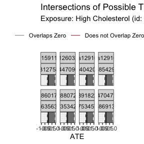

```r
cholesterol_heart_attack_intersection_bounds <- cholesterol_heart_attack_both_bounds %>%
  rowwise() %>%
  mutate(intersection_lower = max(SNP1_lower, SNP2_lower),
         intersection_upper = min(SNP1_upper, SNP2_upper),
         bivariate_intersection_lower = max(SNP1_bivariate_lower, SNP2_bivariate_lower),
         bivariate_intersection_upper = min(SNP1_bivariate_upper, SNP2_bivariate_upper),
  ) %>%
  ungroup() %>%
  mutate(contains_zero = intersection_lower < 0 & intersection_upper > 0)

cholesterol_heart_attack_intersection_bounds_plot <- cholesterol_heart_attack_intersection_bounds %>%
  group_by(SNP1, SNP2) %>%
  arrange(intersection_lower) %>%
  mutate(i = row_number()) %>%
  ungroup() %>%
  ggplot(aes(y = i)) +
    geom_vline(aes(xintercept = bivariate_intersection_lower),
               linetype = "dashed") +
    geom_vline(aes(xintercept = bivariate_intersection_upper),
               linetype = "dashed") +
    geom_errorbar(aes(xmin = intersection_lower,
                      xmax = intersection_upper,
                      color = contains_zero),
                  alpha = 0.7) +
    geom_point(data = data.frame(x = 0, y = 10,
                                 contains_zero = FALSE),
               aes(x = x, y = y, color = contains_zero),
               alpha = 0) +
    scale_color_manual("",
                       values = c("grey50", "red4"),
                       labels = c("Overlaps Zero", "Does not Overlap Zero"),
                       breaks = c("TRUE", "FALSE"),
                       drop = FALSE) +
    lims(x = c(-1, 1)) +
    coord_fixed(ratio = 1/350) +
    geom_vline(xintercept = 0) +
    facet_wrap(~SNP1 + SNP2,
               nrow = 2) +
    labs(
      y = "", x = "ATE"
    ) +
    theme_bw() +
    theme(legend.position = "top",
          axis.text.x = element_text(),
          axis.ticks.x = element_line(),
          axis.text.y = element_blank(),
          axis.ticks.y = element_blank())

ggsave(
  plot = cholesterol_heart_attack_intersection_bounds_plot,
  filename = here::here("figures/example_analyses",
                        paste0("cholesterol_heart_attack_intersection_bounds_plot_", cholesterol_experiment$id, "_", heart_attack_experiment$id,".png")),
  width = 8, height = 6, dpi = 300
)


cholesterol_heart_attack_intersection_bounds_plot +
    labs(title = "Intersections of Possible Trivariate Bounds from Bivariate Data",
         subtitle = paste0("Exposure: High Cholesterol (id: ", cholesterol_experiment$id, "). ",
                           "Outcome: Heart Attack (id: ", heart_attack_experiment$id, ")."))
```

# Save Experiment Information

```r
write_csv(x =
            bind_rows(
              smoking_experiment,
              lung_cancer_experiment,
              cholesterol_experiment,
              heart_attack_experiment
            ),
          file = here::here("vignettes_data/example_analyses/experiment_info.csv")
)
```